# 3.1: Overview of Freight Transport

ISE 754: Logistics Engineering, Fall 2026

Two shipments of the same weight are not the same shipment. Their densities decide what the transport costs, and their values decide whether they go by air, road, rail or water.

No new Julia packages used.

No new Logjam functions used.

No companion script.

## 1. Shippers and carriers

Few industrial engineers go to work for a freight carrier. Almost every industrial engineer working anywhere in a supply chain becomes a *customer* of one, and part of their job is to be the interface between the firm and the trucking, rail, or air-cargo company it hires. As a result, freight transport is taken in this lecture from the customer’s perspective rather than the operator’s: not how a carrier schedules its own equipment, but what a shipper needs to know to buy transport well.

From a terminology point of view, there is an important distinction between the terms carrier and shipper:

- **Carrier**: company that transports a shipment using its equipment (hired by shipper)
- **Shipper**: person or company that owns the shipment (customer of carrier)

This is the largest piece of terminology in freight transport, and it runs opposite to ordinary usage. Most people would call the transport company the shipper, since it is the party that ships things. In freight transport the sense is flipped: the party that operates the railcars, trucks and ships is the **carrier**, and the **shipper** is the party that contracts it. Ordering something on Amazon Prime makes the customer the shipper. A second oddity follows from the first, and it is one that students whose first language is not English have raised more than once: if the load goes by rail or by truck, why is the word *shipping*? Shipping in this field means any mode. It is not literally about ships.

The distinction is not merely a vocabulary lesson, because it decides which cost information the rest of Transport draws on. Almost all the costing information available is from the carrier’s point of view: what its equipment costs to operate, what it pays its drivers. The cost analysis in this course is taken from the **shipper’s** side instead, on the assumption that the reader is much more likely to work at a company hiring a carrier than at the carrier.

Carrier and shipper are the first of a good many terms that read oddly, and the reason they read that way is that freight transport is hundreds and in places thousands of years old. Its vocabulary goes back as far as Old English: solid, ordinary words that carry a particular meaning in this field and nowhere else, which is the opposite of how a new field sounds. Learning the terminology is part of learning the subject, and Sec. 8 collects the rest of it.

What is the most significant concept in freight transport? What a shipment is charged for transport is determined by its density. Freight capacity is a combination of the weight and the cube of a load, and in practice, most loads cube out before they weigh out. Weight is what a load physically weighs; cube is the volume it occupies. To *cube out* is to reach the maximum cubic volume before reaching the maximum weight capacity. The two limits arise differently. Weight capacity is set by federal law, which caps payload at 25 tons. Cube capacity is physical, but it is bounded by law as well, since a trailer may be only so wide and so tall before the load has to be flagged as oversize.

## 2. Transport modes and costs

As listed in Table 1, the different modes of transport can be distinguished by what it costs to move one ton, one mile. The feasibility of using each mode to transport a load is determined by whether the per-ton value of the load can bear that cost. Compared to other modes, air freight is the only one where load weight is a real cost.[^1] For the other modes, it is a capacity constraint, binding for dense freight but not for most general merchandise.

Table 1: Transport modes and their cost per ton-mile.[^2][^3]

| Mode | Cents per Ton-Mile | Relative to Water |
| --- | --- | --- |
| Water | 2.11 | 1 |
| Rail | 4.23 | 2 |
| Road | 18.83 | 9 |
| Air | 137.49 | 65 |

Water here usually means ocean transport: a container from China to the west coast of the United States. Just over two cents moves one ton one mile that way, averaged over the whole world, and since the figure varies with the origin and destination the absolute numbers are useful but not very useful. The right column is the one to keep in mind. Taking water as 1, rail is about twice as costly, and its advantage over water is that it can go where water cannot. A standard 53-foot interstate trailer costs about nine times water and about four times rail.

Everything else being equal, the ordering in the table implies a mode preference: push as much onto water as the geography allows; where there is no river and no ocean, the next best is rail; where there is no rail line, road; and last, air. What decides the matter where there is a genuine choice is how valuable the goods are and how fast they are needed. On the ratios alone, everything that could go by rail should. What kept the traffic on trucks was dependability, or rather rail’s lack of it: a railcar loaded in Raleigh went into a black box, and until it surfaced in Los Angeles nobody knew where it was, the railroad included. Sec. 6 returns to what closed that gap.

The same ordering once drove a speculative boom. For about fifty years, canals were the Silicon Valley of their day and every government was building them, precisely because the economics of water transport are as cheap as Table 1 says. The first canals were cut in the good locations and did well; by the 1840s and 1850s they were being cut in locations that were not good. Railroads arrived at the same moment, and although rail is *less* efficient than a canal by the measure in the table, it is far cheaper to build, so a great many canal companies went bankrupt. Air, at 65 times water, is the other end of the same trade-off, and what sits on the far side of it is the value of the goods. A highly valued product is expensive simply to keep: it has to be financed, so every week it spends anywhere costs something in capital alone, and that cost can justify flying it. A cheap product sitting for weeks costs almost nothing, so nothing justifies the freight.

The trade-off is not always resolved the way the ratios suggest. Two weeks of national Walmart demand for a textile item, from one Southeast Asian supplier, plausibly fits on a single cargo plane, and plausibly flies, even though the items retail for $4.99 or $9.99: they are small enough that the freight is a minor share of what they sell for. Where the goods are much lower in value, getting the freight right is what matters.

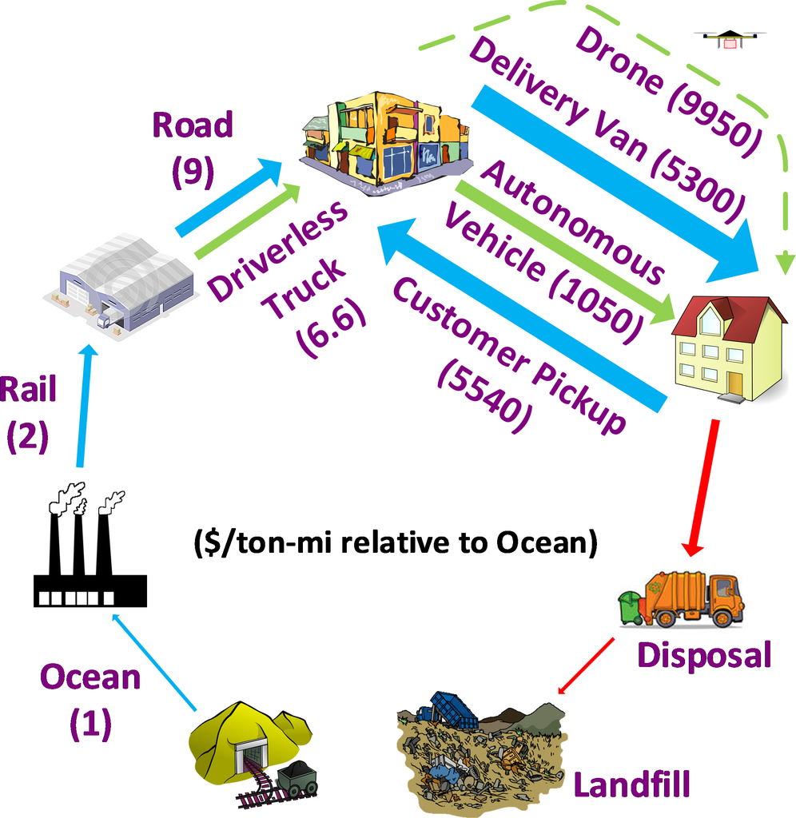

Figure 1: Dirt-to-dirt logistics costs.[^4]

Fig. 1 takes Table 1 and expands it twice. It adds the home, which the table does not reach, and it closes the loop: goods that reach a home eventually have to be disposed of and end at a landfill. That closing leg, from the home back to the landfill, is *reverse logistics*, and many of the same techniques apply to it. The upstream numbers are taken from the table: ocean at 1, rail at 2, road at 9. They come from a white paper written for the material-handling industry in the fall of 2020, which needed a cost for every mode, and *dirt-to-dirt logistics cost* is what that exercise produced. Raw material moves by ocean where ocean is possible, then rail, then road. The interesting part of the figure is the other end: the last mile, from the distribution center to the home.

Set beside it, the delivery van is 5300, for non-perishable and non-priority goods: the kind of thing that can sit on a porch for a couple of hours, which excludes frozen food and most groceries. The two numbers very nearly match, and that is an explanation of something otherwise puzzling about 2020. When people switched from going to the store to ordering everything on Prime, nobody suddenly paid twice as much for everything, because the two legs cost about the same. The drone, at 9950, is about twice the delivery van, and the reason is worth being precise about. A drone’s operating cost is not especially high. Its *payload* is small, and the measure in Fig. 1 is the cost to move one ton, so a small payload is what makes the ratio large.

The autonomous vehicle, at 1050, is where the figure says the opportunity is. What makes the delivery van expensive is also what makes it inflexible: to use the driver fully, the route has to carry about 180 stops a day, which is why an Amazon delivery cannot be scheduled into a thirty-minute window and arrives sometime during the day instead. Remove the driver and put warehouses closer to houses, and the best case is about 1000, close to a five-fold improvement over having the customer go to the store. Compare that with the driverless truck, which the figure puts at 6.6 against road’s 9, a saving of a quarter or so. The two differ because of what labor is a share *of*. Against the cost of operating a tractor-trailer, the driver is not that much; on an Amazon delivery van the driver is almost the whole cost, so removing that driver moves the number proportionally much further. The opportunity is in the last mile, not on the interstate.

Freight transport decisions are mostly tactical, in contrast to strategic location decisions. Trucks resell readily, so a couple bought and not needed go back to a ready market, whereas a customized facility built in the wrong place may salvage for a fraction of what it cost, which makes a bad decision about where to locate, or about how many facilities to build, expensive in a way a bad decision about transport is not. What the tactical decision asks for instead is a finer resolution.

That finer resolution is what the rest of Transport is about. Location works with one monetary weight per facility, usually an aggregate over everything that facility ships. Transport works lane by lane, with different equipment on each, so the same question is asked at a much finer grain. The larger data requirement follows from the resolution rather than from the subject intrinsically requiring more data. A monetary weight is in dollars per mile and a flow is in tons per year, so the transport rate is what connects tons to dollars per mile, and its units are dollars per ton-mile. Location took that rate as given. Determining that rate is what is covered in Lecture 3.2.

In order to determine the cost to transport a shipment, a quote could just be requested from a carrier, and for one shipment that is the easiest thing to do. It says nothing, though, about whether the quote is reasonable: quoted two dollars a mile, a shipper with no reference point cannot say whether that is a good price or a bad one. In transportation everything is negotiable, which makes an independent way of arriving at what a shipment *should* cost an especially valuable way to evaluate the quote itself.

## 3. U.S. logistics costs

As shown in Table 2, the total U.S. logistics costs for 2021 were $1.847 trillion, up 11% from 2020.[^5] This represents 8.03% of the U.S. Gross Domestic Product (GDP). In 1981, the first full year of trucking deregulation, logistics costs were 16.2% of GDP[^6]; in 2000, they were 10.2%,[^7] and in 2009 they were 7.37%, a record low percentage of GDP until 2020’s 7.22%.[^8] In 1981, transportation and carrying costs represented 45% and 51% of total costs, respectively[^9]; in 2016, they represented 64% and 29% of the costs, respectively. In 2016, intercity truck transport (full and LTL) alone represents 37% of the total transportation costs and over 23% of total logistics costs, parcel has surpassed rail for the first time, and total inventory carrying costs as a percentage of the $3.202 trillion total business inventory were 15.65%.

Table 2: Total 2021 U.S. Logistics Costs.[^10]

|  | **$ Billion** |
| --- | --- |
| **Transportation Costs** |  |
| Motor Carrier: |  |
| Full truckload | 332 |
| Less-than truckload | 83 |
| Private or dedicated | 415 |
| Parcel | 135 |
| Rail: |  |
| Carload | 72 |
| Intermodal | 16 |
| Airfreight | 53 |
| Water | 32 |
| Pipeline | 67 |
| Total Transportation Costs | 1,206 |
| **Inventory Carrying Costs ($3,202[^11] billion total inv.)** |  |
| Financial cost (WACC × total inventory) | 165 |
| Storage | 186 |
| Other (obsolescence, shrinkage, insurance, others) | 150 |
| Total Carrying Costs | 501 |
| **Other Costs** |  |
| Carriers’ support activities | 77 |
| Shippers’ administrative costs | 63 |
| Total Logistics Costs | 1,847 |

That total is a significant share of the whole economy, and the first thing to take from the table is a proportion rather than the total itself. Freight transport is not all of logistics, but it is **nearly two-thirds** of what the country spends on logistics.

The rest is the cost of holding goods rather than moving them, and it divides about equally between three lines, of which the one whose name says least is the one worth explaining. *Financial cost* is the financing needed to cover the goods sitting in storage: inventory has to be paid for before it is sold, so it is carried the way any other asset is carried.

It can run the other way too. A grocer with thirty days to pay its supplier, selling the bananas in ten, holds what it owes for the remaining twenty days and can finance other operations with it, so the delay in payment earns rather than costs. Whether inventory is a cost or a source of funds turns on how fast it moves against how long the terms are.

Dividing the total carrying cost in Table 2 by the total business inventory it is held against gives the inventory carrying rate the data implies:

$$h \approx \frac{501}{3202} = 15.65\%
\tag{1}$$

where

**$h$**

= inventory carrying rate.

That is the annual cost of holding inventory as a fraction of its value. The rate in Eq. 1 is what the data shows, and it is not the number to use. It is an aggregate over all logistics, dragged down by a great deal of low-value material: cement and building supplies, heavy and awkward to move and worth little per ton, so cheap to hold. That biases the average downward, and the working rule of thumb for this course is **30%**. The reason is that the discrete manufactured goods considered here are typically of higher value than building supplies and the like.

That makes three design parameters worth carrying in the head: about two dollars a mile to move a truck, a circuity factor of 1.2 to turn a great-circle distance into a road distance, and a 30% inventory carrying rate. More of them accumulate over the course. What they buy is not a detailed analysis, which is always available; it is a number a level better than a guess, arrived at on one’s feet.

Table 3 puts the same total against the whole gross domestic product, year by year. The 2021 figure is about 8%, and the series holds at 8 or 9% through 2023. The record low is 2020 at 7.22%, for the obvious reason: the economy came to a standstill. The record high runs all the way back to 1981, at 16%. The parenthesized pairs are the split between transport and inventory, and they are the more interesting column. In 2021 it is about two-thirds transport and one-third inventory; in 1981 it was essentially half and half.

Table 3: Logistics cost as a percent of GDP.

| Year | % of GDP (Tran/Inv) | Year | % of GDP (Tran/Inv) |
| --- | --- | --- | --- |
| 1981 | 16.2% (45/51) | 2018 | 8.0% (63/30) |
| 2000 | 10.2% | 2019 | 7.66% |
| 2004 | 8.6% | 2020 | 7.22%[^12] |
| 2007 | 9.9% | 2021 | 8.03% (65/27) |
| 2009 | 7.4% | 2022 | 9.04% |
| 2011 | 8.6% | 2023 | 8.76% |
| 2013 | 8.2% | 2024 | 8.8% |
| 2016 | 7.5% (64/29) | 2025 | 7.8% (62/30)[^13] |

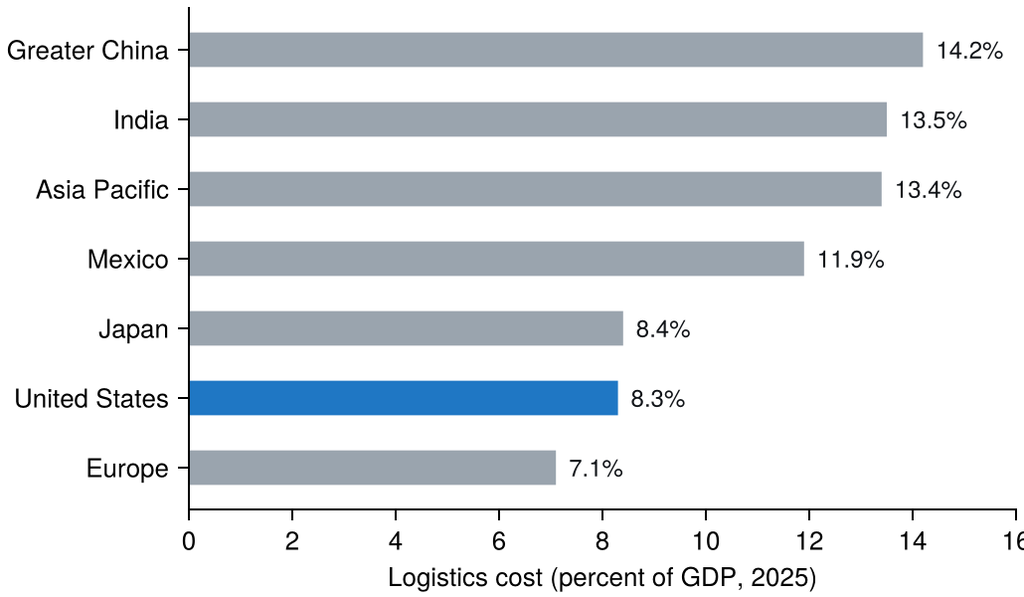

Figure 2: Logistics cost as a percent of GDP, by country.[^14]

In Fig. 2, all three of the most developed economies, Europe, the United States, and Japan, have the lowest logistics cost as a percentage of GDP. What is interesting is that the United States achieves that low percentage in a different manner than Europe and Japan. The U.S. has the lowest transport cost on a per-ton-mile basis,[^15] but being a continental-sized country with low population density, requires about three times as many ton-miles on a per capita basis.[^16]

Geography is the principal reason U.S. per-ton-mile transport costs are low. It has many natural harbors on both coasts, long-distance navigable inland waterways, and many 500-plus-mile hauls, which make rail feasible. The 500-mile threshold is economic rather than physical, since rail is always possible. Below it the hassle decides: a truck makes a direct delivery in about a day, where rail means a day to the yard, another waiting to be loaded, a day or two moving, and a day at the far end. One day against three or four is not worth the saving. Past 500 miles the trucking cost has grown enough that it is.

**NoteIs driving on the right arbitrary?**

Is driving on the right arbitrary? No, it has to do with logistics:

- due to the widespread use of mule trains in the U.S. for freight transport, most mule train drivers were right-handed, so they sat on the left rear mule to free their right hand to control the mules;
- prior to this, riding and driving was on the left, which freed the right hand to grip a sword;
- swords were obsolete by the time the U.S. was settled.

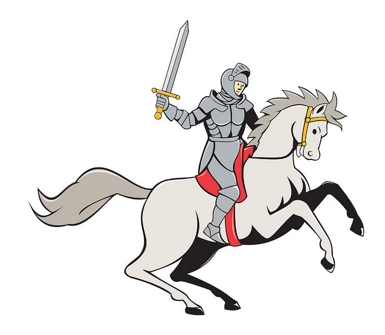

Figure 3: The older convention, and its reason.[^17]

Start earlier. For five or six hundred years most travel was on the *left*, and right-handedness is the reason for that too, reaching a different conclusion. A right-handed rider carries the sword in the right hand (Fig. 3). Passing a stranger of unknown intent, keeping to the left puts the sword hand toward him and the undefended side away; passing on the right leaves that side open. Both parties protected themselves the same way, so the left was the default nearly everywhere.

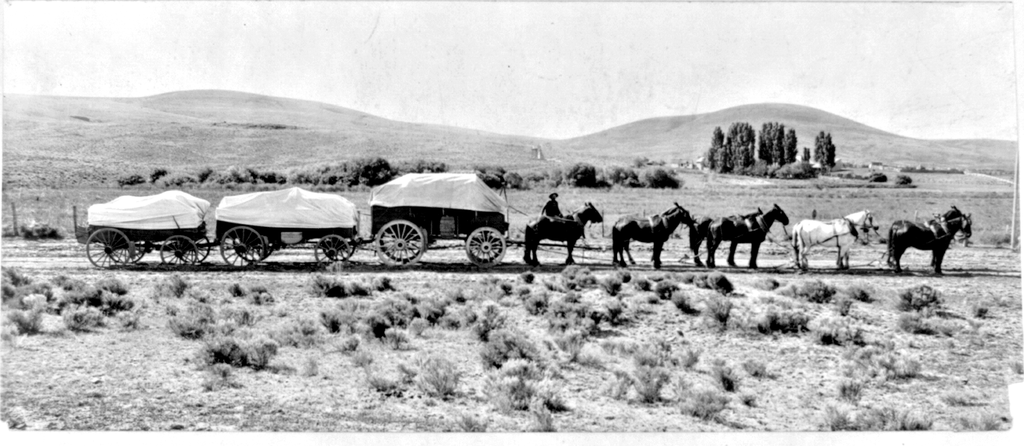

Which of the two he rides is decided by his hands. Sitting on the *left* mule of the rear pair, a right-handed driver can reach all six with the whip, and for a right-handed driver that is the efficient seat.

Guns ended the sword argument. Firearms had been in use for centuries before Europeans colonized North America, so by the time the question arose here the sword was a non-issue and the cost of moving freight was the only live consideration. Americans drove on the right. England, already on the left and locked in, did not switch, because changing the side of the road is an enormous undertaking.

Continental Europe was on the left too, until Napoleon. Taking power in France around 1800 and interested in what was new, he saw what the Americans were doing and ordered France to the right; having conquered most of the continent, he ordered the rest of it to the right as well. The map of who drives where is therefore largely a map of whom he did not conquer. England he tried and failed; Sweden he never reached; Japan is an island and was never conquered. All three stayed on the left.

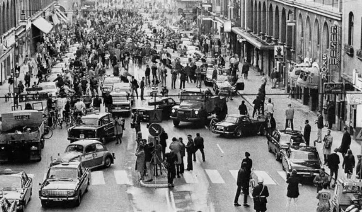

Figure 5: Stockholm on the morning of 3 September 1967, the day Sweden changed sides.[^19]

Sweden is the exception that shows the scale of it. Months of preparation went into a single Saturday midnight: every sign was ready, the country shut down for about six hours, crews were staged across it, and in those six hours the signs were changed. Fig. 5 is the Sunday morning that followed in Stockholm, a country working out how to drive. That is recent enough to be within living memory.

The point of the digression is the size of the thing it illustrates. Freight transport mattered enough to determine which side of the road half the world drives on. It was not an arbitrary flip of a coin.

## 4. Containerization

Malcom McLean is, arguably, one of the two or three people who have had the biggest impact on global trade since WWII. He patented his innovation, and then immediately gave it away. He was a trucker from Maxton, North Carolina.

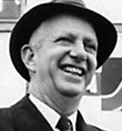

Malcom McLean.

[figure not shown]

Maxton, North Carolina.

[figure not shown]

The container, patented and given away.

Figure 6: Malcom McLean, of Maxton, North Carolina, and the innovation he patented and gave away.[^20]

Containers were the first “packetized” transport network and were developed in the 1950’s by North Carolina trucker Malcolm McLean, who started Sea-Land based in Charlotte.[^21] Intermodal ISO containers conform to the International Organization for Standardization (ISO) container manufacturing standards. They are used to facilitate loading and unloading at ports and to allow the container to be transported using other modes of transport like trucking and rail. The capacity of a ship is measured in TEUs (Twenty-foot Equivalent Units), an international standard.

The man in Fig. 6 is Malcom McLean. What he patented was not a box but a *size* of box, and, more important still, the fitting by which one box locks to another. Standardizing those two things is what let everyone else build around them. Before it, containers came in every dimension, so no port could justify specialized equipment for any of them; afterwards, cranes and ships could be designed for one shape and built to handle it efficiently. He gave the standard away rather than keeping it, and the giving away is the reason it became one.

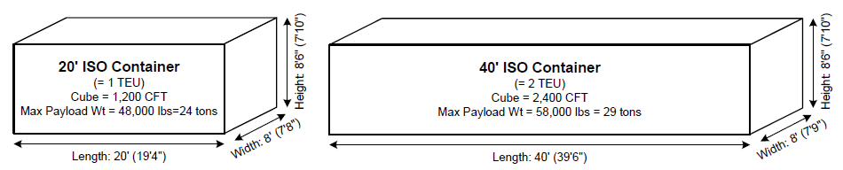

Figure 7: The two standard ISO containers.

The ISO container is used to transport 90% of international trade. The standard box is 40 feet, with a cube capacity of about 2,400 cubic feet, and the half size is the 20-foot container that gives the TEU its name (Fig. 7). A 40 ft container counts as 2 TEU. One detail is worth noticing for what it says about how a standard spreads. The rest of the world is metric, and yet containers everywhere are 20 or 40 *feet*. This is one of the last places English units survive in international practice, and the reason is simply that the man who set the standard was American. Every box also carries its own identity, stamped on the door and read in Fig. 8.

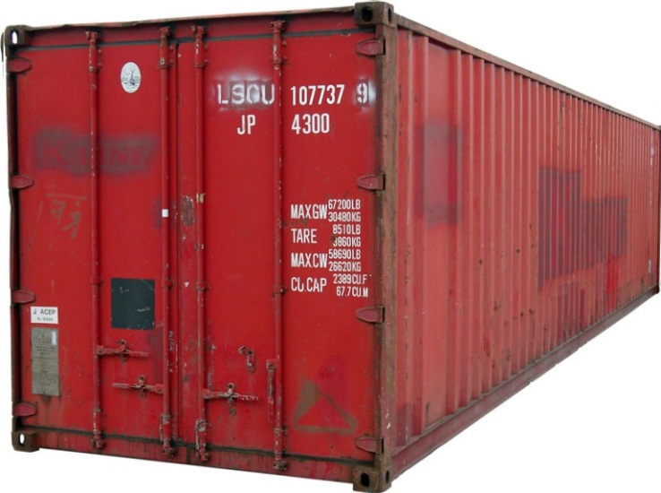

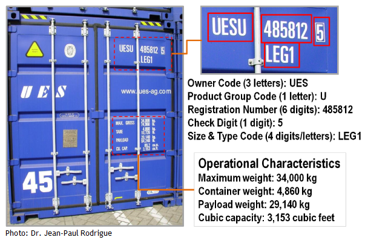

Figure 8: A container and its BIC code, which identifies the box and states what it may carry.[^22]

Nothing was adopted quickly. In the late 1960s only two cases had enough value at stake to justify the new technology, and both turn on the same property: a locked container is hard to steal from. The first was the U.S. Army, shipping rifles to Europe. Freight moved in boxes was easy to lose track of and easy to pilfer; a sealed container went from the United States to its destination secure. The difficulty was the return leg, since Europe was not selling arms back. The backhaul was Scotch whisky, for the same reason and worse. Cases arriving at the port of New Jersey lost one or two to pilferage every time they were unloaded, and near Christmas the loss could run to ten or fifteen percent. A container that could be sealed in Scotland and opened at the distribution center was worth paying for. Those two cargoes carried the standard until everyone else caught up.

[figure not shown]

Figure 9: The Freightos Baltic Index, through 2022.[^23] Later readings from the same index: 12 September 2023, $1,455; 24 September 2024, $4,701; 7 September 2026, $3,520.[^24]

Set that against the trucking rate from Sec. 2. The $2 per mile is a stable baseline, moving little even as fuel prices do, and it wants adjusting for current cost rather than replacing. Container rates do not behave that way at all: Fig. 9 runs from about $2,000 to $10,000 and back again, which makes any analysis resting on one of them hard to trust for long. That volatility, rather than the level, is the reason ocean rates are left to the specialists and this course stays with the truck.

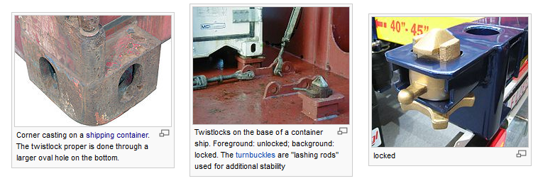

Figure 10: Corner casting, twistlocks on a ship’s deck, and one locked.[^25]

The fitting itself is called a **twistlock**, and it is as simple as it sounds. It sits in the corner casting between two stacked containers (Fig. 10); pulling the handle turns it, and the turn locks the upper box to the lower one. Unlock it and the box lifts off. That is the whole mechanism, and in some sense the twistlock is what made the global economy work: it is the piece McLean patented, and little things of that kind make a large difference to how well a system runs (a clip of a twistlock in action is worth a look[^26]).

## 5. Ocean and intermodal transport

The cycle in Fig. 11 is the one a container runs. It reaches a port, specialized cranes load it onto a ship, and it is offloaded at a port at the far end. From there it goes by truck, or by rail, where two containers can be double-stacked on one flatcar, until it reaches its destination and is unloaded. Switching between more than one mode of transport this way is what **intermodal** means: ocean to rail to road, on the same box.

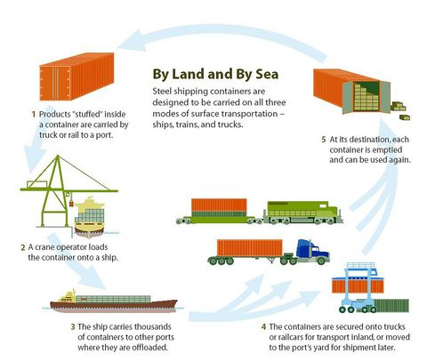

[figure not shown]

Figure 11: The intermodal cycle, and the CenterPoint intermodal center outside Chicago where it happens at scale.[^28]

What that box costs to move is the next question, and Fig. 12 estimates it between selected ports. Shanghai to Los Angeles and Long Beach is $2,620 in the loaded direction and $1,400 coming back. That asymmetry is a complication peculiar to ocean transport: the cost one way is usually not the cost of the other, and the reason is an imbalance of supply and demand. Far more freight wants to move from Shanghai to the United States than the reverse, so the return leg is much the cheaper of the two.

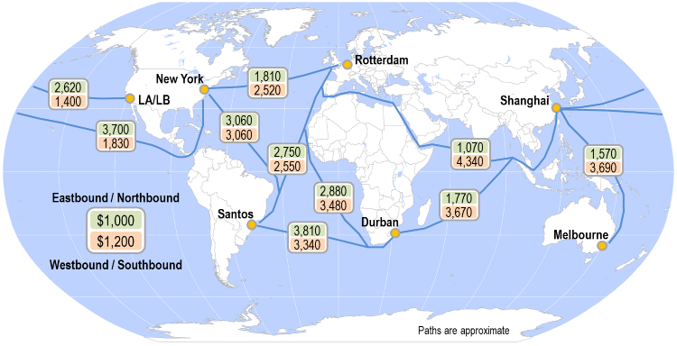

Figure 12: Maritime transportation rates for a 40-foot container between selected ports, 2010. The two figures on a lane are its two directions.[^29]

How long it takes is a separate question from what it costs, and Fig. 13 answers it for the same origin. Shanghai to Norfolk is about 25 days of ocean transport. Shanghai to Long Beach is 13, and Chicago is another five on top of that, by rail. The five is the interesting number, because only a day or two of it is movement: a day or two to come off the ship and onto a railcar, two days running, and another day or two to be unloaded at the far end. Most of the time a container spends in transit, it is not in motion.

[figure not shown]

Figure 13: Transit times from Shanghai, and the North American routing options, in days.[^30]

A long-haul trucker shown this figure caught that point immediately. He drove one of the routes on it and knew it did not take eight days, and he was right: the eight is from the ship’s arrival to the load being unloaded in New York, and the driving inside it is two or three days. The rest is port. A table of transit times is therefore not a table of travel times, and reading it as one overstates how far apart two places are.

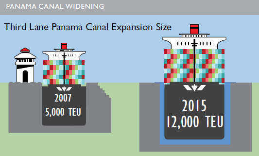

Figure 14: The third set of locks, and the ship each generation admits.[^32]

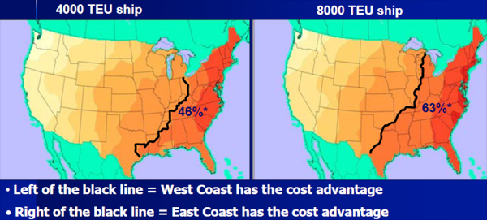

Figure 15: Where the cost advantage lies, for a 4,000 TEU ship and an 8,000 TEU ship. The black line is the break-even.[^33]

What the country did about it started long before the canal was finished, which is the part worth taking away. The expansion was known to be coming by the late 1990s and took ten or twelve years to build. Target, Walmart and the other large retailers began in 2000, building distribution centers and infrastructure against a change that had not happened yet, and new rail was laid from the East Coast ports to places that until then were served only from the West. Freight infrastructure has lead times measured in decades, and the response to it has them too.

It runs the other way too. Drought has since forced the canal to cut the number of ships it takes each day, and that reduction is enough that Mexico has looked at building an overland alternative across its own territory. A waterway that moved the country’s distribution map once can move it again, and the thing that constrains it need not be engineering.

## 6. Rail and railcar tracking

Freight can be transported by carload (CL) or less-than-carload (LCL), the rail counterpart of the truckload distinction TL (truckload) and LTL (less-than-truckload). Truck trailers can be transported on flatcars (TOFC), and ocean containers can be double-stacked on flatcars (COFC): piggyback and doublestack, the two arrangements Fig. 17 compares. Fig. 16 shows a typical boxcar. RailInc is a company located in Cary, NC that tracks the movement of railcars throughout the U.S.

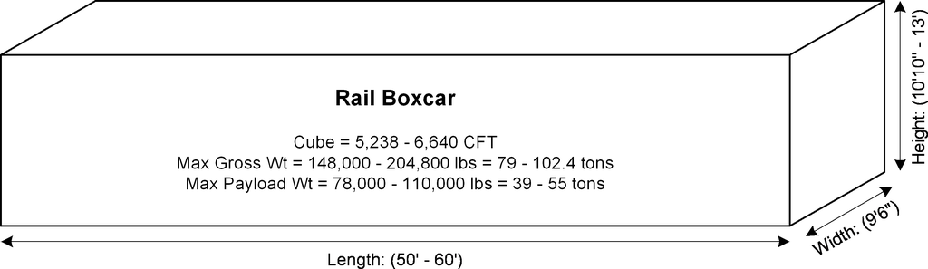

Figure 16: The rail boxcar, with interior dimensions in parenthesis.

Doublestacking cuts the cost of moving a container by roughly half, and Fig. 17 shows why it is not simply a matter of deciding to do it. The complication was the bridges and the tunnels. Much of the American rail network’s grade crossing was built in the 1920s, 1930s and 1940s, when the container did not exist and no one had any reason to imagine a car standing eighteen feet tall; a rail car then was not much taller than its load.

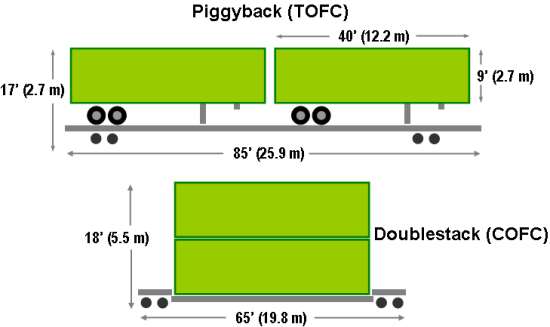

[figure not shown]

Figure 17: Piggyback against doublestack, and a doublestack train.[^34]

So thousands of miles of American rail carried bridges the stacked car could not pass under, and over the following twenty to forty years the railroads raised them. Not the government: private railroads, CSX among them, spending tens and perhaps hundreds of billions of dollars on work as unglamorous as lifting a bridge a few feet or lowering the track beneath it, whichever came cheaper. One such job is under way in Raleigh, a tunnel under Blue Ridge Road by the state fairgrounds, five years in so far. That is one crossing. The investment is that job repeated thousands of times.

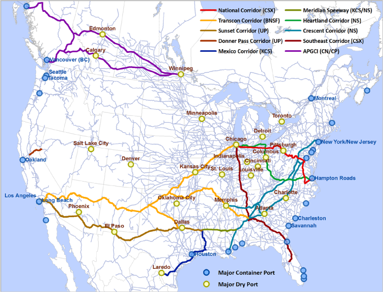

Figure 18: Major North American rail corridors improved since 2000.[^35]

What the money bought is Fig. 18: a set of corridors on which a container can travel doublestacked from one side of the continent to the other. A box landed at Los Angeles goes on rail and stays stacked the whole way. Where it stops is notable. The eastern end of that run is Lakeland, Florida, which is the same answer given in Table 4 in Lecture 2.3 and Ex. 8 in Lecture 2.3, where Lakeland was the best location to build a warehouse in Florida; this provides confirmation of the analysis.

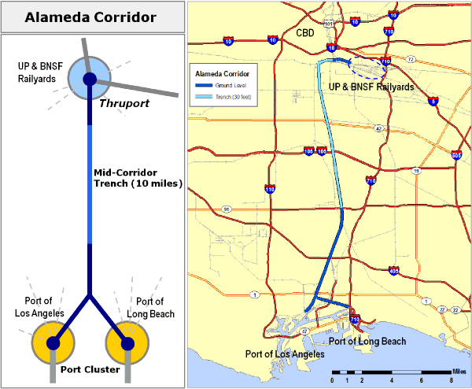

[figure not shown]

Figure 19: The Alameda Corridor: ten miles of trench between the ports and the railyards, and traffic passing over it.[^36]

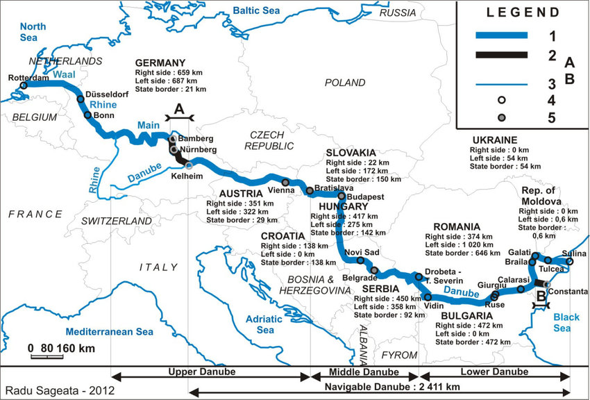

Figure 20: The Rhine–Main–Danube axis: navigable rivers and the canals that join them.[^37]

The third is older, and the scale of it is the point. The Rhine–Main–Danube axis in Fig. 20 runs from Constanța on the Black Sea to Rotterdam on the North Sea, so a barge can cross Europe on water the whole way. It was completed in **1992**. Construction started in **793**, on the order of the emperor Charlemagne. Freight infrastructure is not something that happens quickly.

Automatic identification (Auto-ID): real-time data collection and identification. First use case that justified its development was all weather tracking of moving railcars. Kartrak was a colored bar code system developed in the mid-1960s and tested in northern Norway. The colored strips in Fig. 21 were how a railroad kept track of where its cars were. The stripes in the colored codes faded, and the technology became the first RFID (radio-frequency identification) tag, which led to the modern UPC barcode. The line from Kartrak to the supermarket is direct. The engineer who spent the winter in Norway was among the people who later developed the UPC code for the grocery industry. Automatic identification was invented to find railcars, and the checkout scanner is what it turned into.

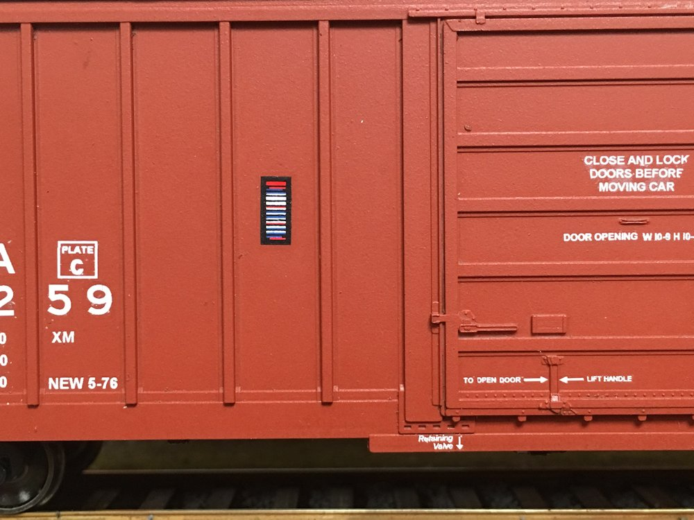

Figure 21: A Kartrak label: the colored stripes a trackside scanner read.[^38]

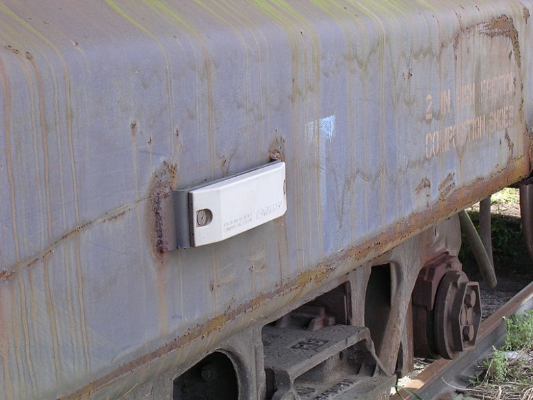

[figure not shown]

[figure not shown]

Figure 22: Automatic Equipment Identification: a tag on the car, a reader beside the track, and the readers of one corner of North Carolina.[^39]

The red dots in Fig. 22 are RFID readers, and every time a railcar passes one it is recorded. A firm shipping by rail can therefore look up its own car online, see where it is at that moment, and estimate when it will reach its facility. Railinc, located in Cary, North Carolina, is a consortium supported by the railroads to run the network of RFID readers. Using Railinc, any shipper can determine the location of its shipments.

This is one of the reasons inventory costs are as low as they are, and the comparison is what makes it clear. Before about 1980, a shipper who handed a load to a railroad lost sight of it, and so did the railroad: the car was somewhere between Raleigh and Los Angeles and would arrive in one week, or two, or three. The railroad knew what happened at each yard as it happened and had no picture of the whole; the network was a black box to everyone including the people running it. Not knowing is what safety stock is for, which is Table 2’s carrying-cost line, so seeing the car is worth money long before it is worth anything else.